# Lec2 Basic Data Manipulation

## Two Parts of Statistics

- Descriptive statistics

collecting, summarizing and presenting data

- Inferential Statistics

drawing conclusions about a population based on sample data

- Cases

objects of interest in a certain study, described by a set of data; eg: customers, voters, patients, students, cars, houses, jobs, companies, dogs, pets

- Random Variables

special characteristics of cases; eg: customers’ satisfactory, voters’ preference, patients’ recovery rates, students’ grades; cars’ gas mileage, etc.

## Data Types

- Numerical (Quantitative)

  **discrete**  
  eg: number of siblings; number of children; defects per day

  **continuous**  
  eg: height, weight, voltage
- Categorical (Qualitative)

  **nominal**  
  eg: marital status, political party, eye color

  **ordinal**  
  eg: satisfaction level, students’ grades

## Data Frames

```r
df = read.csv(file="opendatasites.csv",header=T,sep=",")
head(df)
```

```
         Item                                      Link                   Type
1      Aarhus                       http://www.odaa.dk/ International Regional
2     Alabama                  http://open.alabama.gov/               US State
3     Alberta                   http://data.alberta.ca/ International Regional
4 Albuquerque             http://www.cabq.gov/abq-data/      US City or County
5     Alkmaar            http://www.alkmaar.nl/opendata International Regional
6   Allerdale http://datacatalogs.org/catalog/allerdale International Regional
```

[figure not shown]

## Data Frames

```r
head(iris)
```

```
  Sepal.Length Sepal.Width Petal.Length Petal.Width Species
1          5.1         3.5          1.4         0.2  setosa
2          4.9         3.0          1.4         0.2  setosa
3          4.7         3.2          1.3         0.2  setosa
4          4.6         3.1          1.5         0.2  setosa
5          5.0         3.6          1.4         0.2  setosa
6          5.4         3.9          1.7         0.4  setosa
```

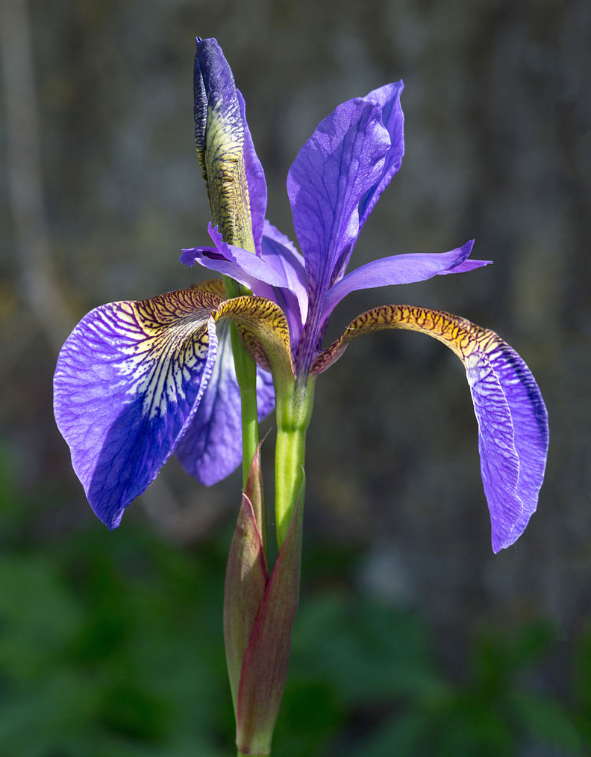

## Data Frames

- Data frame is one of the basic objects in R. It is a 2-dimensional array.

## Data Frames

- Data frame is one of the basic objects in R. It is a 2-dimensional array.
- While matrix always has numbers as entries, data frame can contain various types of data. However, each column is a vector of entries of the same type. Also, all columns are of the same length, so that the data frame has a “rectangular” shape.

## Data Frames

- Data frame is one of the basic objects in R. It is a 2-dimensional array.
- While matrix always has numbers as entries, data frame can contain various types of data. However, each column is a vector of entries of the same type. Also, all columns are of the same length, so that the data frame has a “rectangular” shape.
- Other object types also used for similar purposes are data table and tibble. It is a more modern cousin of data frame.

## Data Frames

- Data frame is one of the basic objects in R. It is a 2-dimensional array.
- While matrix always has numbers as entries, data frame can contain various types of data. However, each column is a vector of entries of the same type. Also, all columns are of the same length, so that the data frame has a “rectangular” shape.
- Other object types also used for similar purposes are data table and tibble. It is a more modern cousin of data frame.
- List can be thought of as a loosely structured data frame.

## Data Frames

```r
head(iris)
```

```
  Sepal.Length Sepal.Width Petal.Length Petal.Width Species
1          5.1         3.5          1.4         0.2  setosa
2          4.9         3.0          1.4         0.2  setosa
3          4.7         3.2          1.3         0.2  setosa
4          4.6         3.1          1.5         0.2  setosa
5          5.0         3.6          1.4         0.2  setosa
6          5.4         3.9          1.7         0.4  setosa
```

```r
str(iris)
```

```
'data.frame':   150 obs. of  5 variables:
 $ Sepal.Length: num  5.1 4.9 4.7 4.6 5 5.4 4.6 5 4.4 4.9 ...
 $ Sepal.Width : num  3.5 3 3.2 3.1 3.6 3.9 3.4 3.4 2.9 3.1 ...
 $ Petal.Length: num  1.4 1.4 1.3 1.5 1.4 1.7 1.4 1.5 1.4 1.5 ...
 $ Petal.Width : num  0.2 0.2 0.2 0.2 0.2 0.4 0.3 0.2 0.2 0.1 ...
 $ Species     : Factor w/ 3 levels "setosa","versicolor",..: 1 1 1 1 1 1 1 1 1 1 ...
```

## `iris` data frame

```r
head(iris)
```

```
  Sepal.Length Sepal.Width Petal.Length Petal.Width Species
1          5.1         3.5          1.4         0.2  setosa
2          4.9         3.0          1.4         0.2  setosa
3          4.7         3.2          1.3         0.2  setosa
4          4.6         3.1          1.5         0.2  setosa
5          5.0         3.6          1.4         0.2  setosa
6          5.4         3.9          1.7         0.4  setosa
```

```r
head(iris, 3)
```

```
  Sepal.Length Sepal.Width Petal.Length Petal.Width Species
1          5.1         3.5          1.4         0.2  setosa
2          4.9         3.0          1.4         0.2  setosa
3          4.7         3.2          1.3         0.2  setosa
```

```r
tail(iris)
```

```
    Sepal.Length Sepal.Width Petal.Length Petal.Width   Species
145          6.7         3.3          5.7         2.5 virginica
146          6.7         3.0          5.2         2.3 virginica
147          6.3         2.5          5.0         1.9 virginica
148          6.5         3.0          5.2         2.0 virginica
149          6.2         3.4          5.4         2.3 virginica
150          5.9         3.0          5.1         1.8 virginica
```

```r
colnames(iris)
```

```
[1] "Sepal.Length" "Sepal.Width"  "Petal.Length" "Petal.Width"  "Species"
```

```r
unique(iris[,"Species"])
```

```
[1] setosa     versicolor virginica
Levels: setosa versicolor virginica
```

```r
dim(iris)
```

```
[1] 150   5
```

```r
nrow(iris)
```

```
[1] 150
```

```r
ncol(iris)
```

```
[1] 5
```

```r
length(iris) ## length of iris as list; same as ncol()
```

```
[1] 5
```

## Basic Data Manipulation

Let’s extract `species` column from `iris`.

```r
spec = iris$Species
head(spec) ## head() works on vectors, not just on data frames
```

```
[1] setosa setosa setosa setosa setosa setosa
Levels: setosa versicolor virginica
```

```r
str(spec)
```

```
 Factor w/ 3 levels "setosa","versicolor",..: 1 1 1 1 1 1 1 1 1 1 ...
```

We see there are 3 different levels/values/categories in the vector `spec`. This can also be found using `unique()` command.

```r
unique(spec)
```

```
[1] setosa     versicolor virginica
Levels: setosa versicolor virginica
```

```r
table(spec) ## how many counts of each level
```

```
spec
    setosa versicolor  virginica
        50         50         50
```

At this point, variable `Species` does not exist. Column `Species` is a part of the data frame `iris`.

```r
Species
```

```
Error in eval(expr, envir, enclos): object 'Species' not found
```

Using the command `attach()`, we attach, to the global environment, all the column vectors of data frame `iris`.

```r
attach(iris)
head(Species)  ## now Species does exist
```

```
[1] setosa setosa setosa setosa setosa setosa
Levels: setosa versicolor virginica
```

## Subsetting R Objects

There are three operators that can be used to extract subsets of R objects.

- The `[` operator always returns an object of the same class as the original. It can be used to select multiple elements of an object. You must close the inquiry by `]`
- The `[[` operator is used to extract elements of a list or a data frame. It can only be used to extract a single element and the class of the returned object will not necessarily be a list or data frame. You must close the inquiry by `]]`
- The `$` operator (as we already saw), is used to extract elements of a list or data frame by literal name. Its semantics are similar to that of `[[`.

Examples:

```r
head(iris[,1:3])
```

```
  Sepal.Length Sepal.Width Petal.Length
1          5.1         3.5          1.4
2          4.9         3.0          1.4
3          4.7         3.2          1.3
4          4.6         3.1          1.5
5          5.0         3.6          1.4
6          5.4         3.9          1.7
```

```r
head(iris[,c(1,3)])
```

```
  Sepal.Length Petal.Length
1          5.1          1.4
2          4.9          1.4
3          4.7          1.3
4          4.6          1.5
5          5.0          1.4
6          5.4          1.7
```

```r
head(iris[,'Petal.Length'])
```

```
[1] 1.4 1.4 1.3 1.5 1.4 1.7
```

```r
head(iris[,c('Sepal.Length','Petal.Length')])
```

```
  Sepal.Length Petal.Length
1          5.1          1.4
2          4.9          1.4
3          4.7          1.3
4          4.6          1.5
5          5.0          1.4
6          5.4          1.7
```

```r
head(iris[c(1,3),])
```

```
  Sepal.Length Sepal.Width Petal.Length Petal.Width Species
1          5.1         3.5          1.4         0.2  setosa
3          4.7         3.2          1.3         0.2  setosa
```

```r
head(iris[iris$Species=='versicolor',])
```

```
   Sepal.Length Sepal.Width Petal.Length Petal.Width    Species
51          7.0         3.2          4.7         1.4 versicolor
52          6.4         3.2          4.5         1.5 versicolor
53          6.9         3.1          4.9         1.5 versicolor
54          5.5         2.3          4.0         1.3 versicolor
55          6.5         2.8          4.6         1.5 versicolor
56          5.7         2.8          4.5         1.3 versicolor
```

```r
dim(iris[iris$Species=='versicolor',])
```

```
[1] 50  5
```

We use logical operators (`&` or `AND`; `|` or `OR`; `!`o r `NOT`) for more sophisticated subsetting.

```r
iris[(iris$Species=='versicolor') & (iris$Sepal.Length<=5.0), ]
```

```
   Sepal.Length Sepal.Width Petal.Length Petal.Width    Species
58          4.9         2.4          3.3           1 versicolor
61          5.0         2.0          3.5           1 versicolor
94          5.0         2.3          3.3           1 versicolor
```

```r
dim(iris[(iris$Species=='versicolor') & (iris$Sepal.Length<=5.0), ])
```

```
[1] 3 5
```

We see there are 3 observations of species versicolor in the data set whose sepal length is not bigger than 5.0.

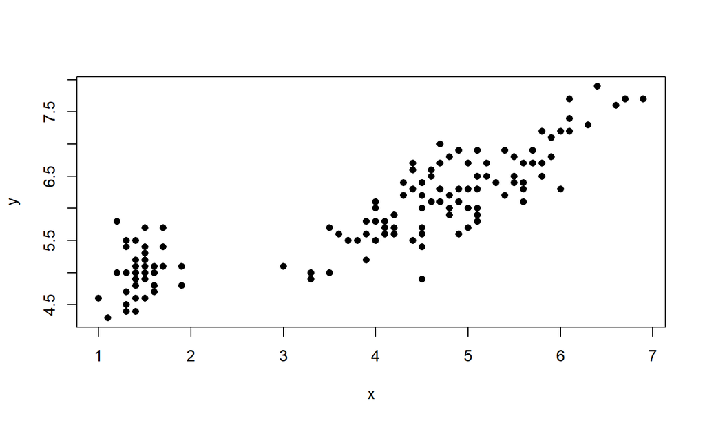

```r
x = iris$Petal.Length
y = iris$Sepal.Length
plot(x,y,pch=16)
```

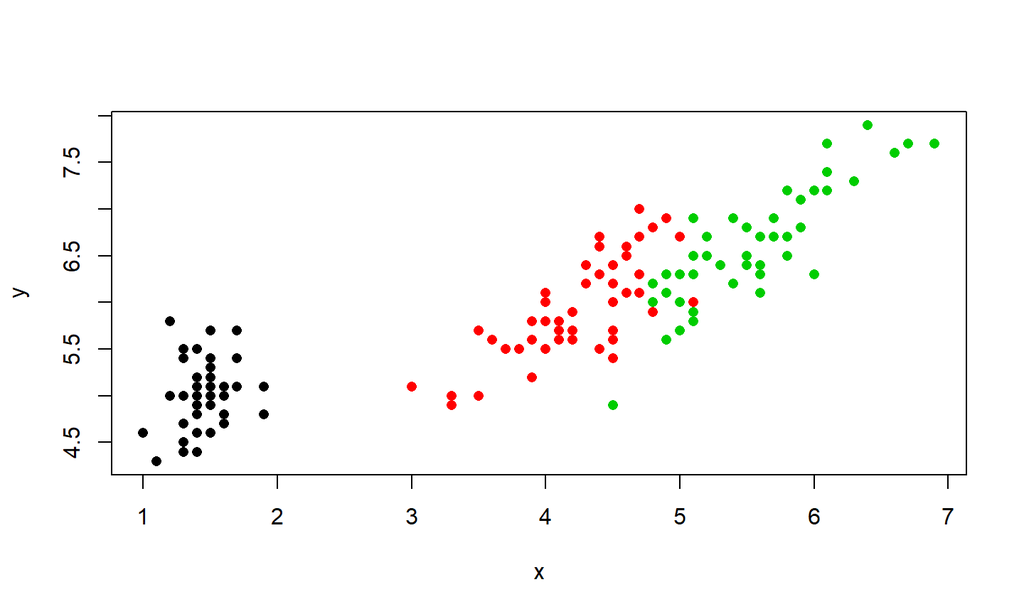

```r
plot(x,y,pch=16, col=iris$Species)
```

## Let’s put some labels…

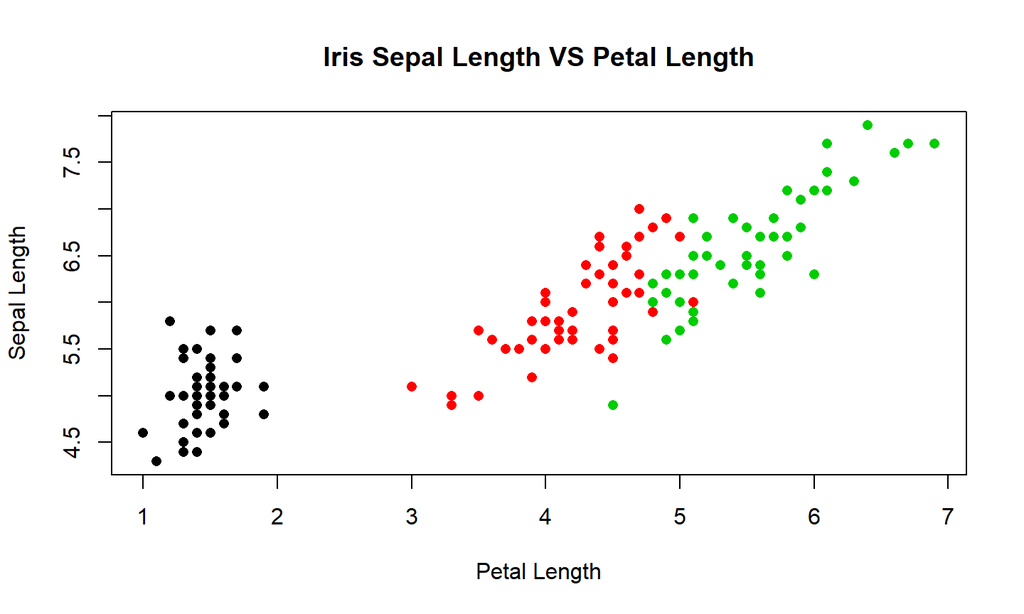

```r
plot(x,y,pch=16, xlab='Petal Length',
                 ylab='Sepal Length',
                 main='Iris Sepal Length VS Petal Length',
                  col=iris$Species)
```

## … and a legend

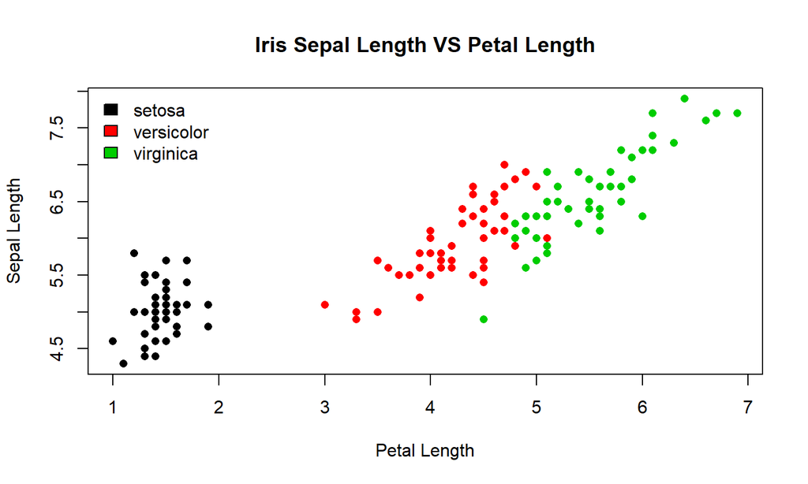

```r
legend("topleft",legend=unique(iris$Species),
       fill=unique(iris$Species),bty='n')
```

Explore the input parameters of `plot()` function by querying

```r
?plot
```

Note that there are several types of plots that can be created by the `plot()` command:

- “p” for points
- “l” for lines
- “b” for both
- “c” for the lines part alone of “b”,
- “o” for both ‘overplotted’,
- “h” for ‘histogram’ like (or ‘high-density’) vertical lines,
- “s” for stair steps,
- “S” for other steps, see ‘Details’ below,
- “n” for no plotting.
- You can find various cheatsheets and websites with R base graphs (for example, http://www.joyce-robbins.com/wp-content/uploads/2016/04/BaseGraphicsCheatsheet.pdf
- We will also discuss a powerfull `ggplot2` package for producing all sorts of plots, but right now we are focusing on functions from the basic `graphics` package, installed by default, i.e. as a part of R installation.

```r
data(airquality)
air = airquality
head(air)
```

```
  Ozone Solar.R Wind Temp Month Day
1    41     190  7.4   67     5   1
2    36     118  8.0   72     5   2
3    12     149 12.6   74     5   3
4    18     313 11.5   62     5   4
5    NA      NA 14.3   56     5   5
6    28      NA 14.9   66     5   6
```

```r
unique(air$Month)
```

```
[1] 5 6 7 8 9
```

```r
library(dplyr)
```

[output not shown]

[output not shown]

[output not shown]

```r
months = recode_factor(air$Month, '5'="May", '6'="June", '7'="July", '8'="August", '9'="Septemper")
unique(months)
```

```
[1] May       June      July      August    Septemper
Levels: May June July August Septemper
```

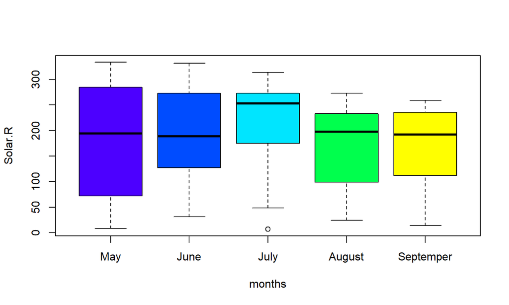

```r
boxplot(Solar.R~months, data=air, col=topo.colors(length(unique(months))))
```

Unfortunatelly, to add a graph on the top of already existing plot, we need one of the “annotating” functions. For curves, that’s `lines()`, for scatter plot, it’s `points`, and for straight lines, it’s `abline`. For example, in our boxplot, we can add a horizontal line through the mean of all `Solar.R` values. Let’s see what this mean is:

```r
mean(air$Solar.R)
```

```
[1] NA
```

The reason why it is `NA` is because there are `NA` values in the vector `air$Solar.R`. The missing value `NA` (not available) is quite contagious, in the sense that it causes many calculations to become `NA`, just like in this case. To overcome this problem, there is an input parameter `na.rm` within `mean()` function. If you query

```r
?mean
```

```r
mean(air$Solar.R, na.rm=TRUE)
```

```
[1] 185.9315
```

For lines, we use `abline`

```r
abline(h=mean(air$Solar.R,na.rm=TRUE), col='red', lty='dashed', lwd=2)
```

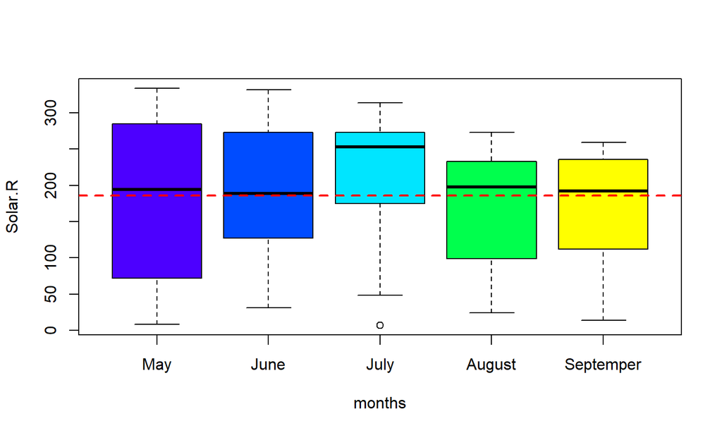

```r
boxplot(Solar.R~months, data=air, col=topo.colors(length(unique(months))))
abline(h=mean(air$Solar.R,na.rm=TRUE), col='red', lty='dashed', lwd=2)
```